# Statistical Learning - Group Work - Final Presentation

Group 16: Angelina Khatiwada & Rijin Baby

18/06/2021

# Data Set: [in-vehicle coupon recommendation](https://archive.ics.uci.edu/ml/datasets/in-vehicle+coupon+recommendation)

This data was collected via a survey on Amazon Mechanical Turk. The survey describes different driving scenarios including the destination, current time, weather, passenger, etc., and then ask the person whether he will accept the coupon if he is the driver.

- Multivariate dataset
- Number of Instances: 12684
- Number of Attributes: 23

### Key Attribute Information:

- **destination: Home, No Urgent Place, Work**
- passanger: Alone Friend(s), Kid(s), Partner
- **coupon: Bar, Carry out & Take away, Coffee House, Restaurant(<20), Restaurant(20-50)**
- expiration: 1d, 2h (the coupon expires in 1 day or in 2 hours)
- Bar: never, less1, 1~3, gt8, nan4~8 (feature meaning: how many times do you go to a bar every month?)
- **CoffeeHouse: never, less1, 4~8, 1~3, gt8, nan (feature meaning: how many times do you go to a coffeehouse every month?)**
- CarryAway:n4~8, 1~3, gt8, less1, never (feature meaning: how many times do you get take-away food every month?)
- RestaurantLessThan20: 4~8, 1~3, less1, gt8, never (feature meaning: how many times do you go to a restaurant with an average expense per person of less than $20 every month?)
- toCoupon_GEQ15min:0,1 (feature meaning: driving distance to the restaurant/bar for using the coupon is greater than 15 minutes)
- direction_same:0, 1 (feature meaning: whether the restaurant/bar is in the same direction as your current destination)
- **Y:1, 0 (whether the coupon is accepted)**

## Data Preparation

**1) Load Libraries & Read Dataset**  
**2) Missing & unique value check**

```
## Columns with missing value
```

```
## [1] "car :100%"                   "Bar :0.84%"
## [3] "CoffeeHouse :1.71%"          "CarryAway :1.19%"
## [5] "RestaurantLessThan20 :1.02%" "Restaurant20To50 :1.49%"
```

```
## Column with unique value
```

```
## toCoupon_GEQ5min
##               20
```

**3) Creating New Variables** - occupation class - Expiration weightage (numeric, scaled)

| occupation_class | Actual_occupation |
| --- | --- |
| Craft and related trades workers | Installation Maintenance & Repair |
| Craft and related trades workers | Transportation & Material Moving |
| Craft and related trades workers | Food Preparation & Serving Related |
| Craft and related trades workers | Building & Grounds Cleaning & Maintenance |
| Others | Office & Administrative Support |
| Others | Production Occupations |
| Others | Farming Fishing & Forestry |
| Professionals | Architecture & Engineering |
| Professionals | Education&Training&Library |
| Professionals | Healthcare Practitioners & Technical |
| Professionals | Management |
| Professionals | Arts Design Entertainment Sports & Media |
| Professionals | Computer & Mathematical |
| Professionals | Legal |
| Professionals | Business & Financial |
| Retired | Retired |
| Service and sales | Sales & Related |
| Service and sales | Personal Care & Service |
| Service and sales | Protective Service |
| Student | Student |
| Technicians & prof | Healthcare Support |
| Technicians & prof | Life Physical Social Science |
| Technicians & prof | Community & Social Services |
| Technicians & prof | Construction & Extraction |
| Unemployed | Unemployed |

**4) Missing imputation knn approach**

```r
  library(VIM)
  cleaned_data <- kNN(
                coupon_data,
                variable = c("Bar","CoffeeHouse","CarryAway","RestaurantLessThan20","Restaurant20To50")
                , k = 5)
  cleaned_data <- cleaned_data[,1:ncol(coupon_data)]
  # coupon_data_final %>% map(table)
  # colMeans(is.na(cleaned_data))*100
```

## Plotting data columns

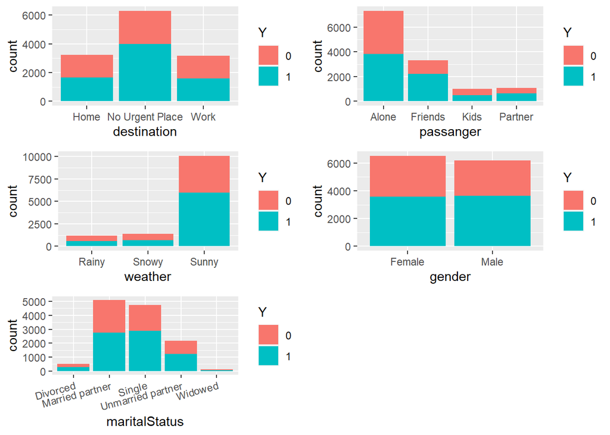

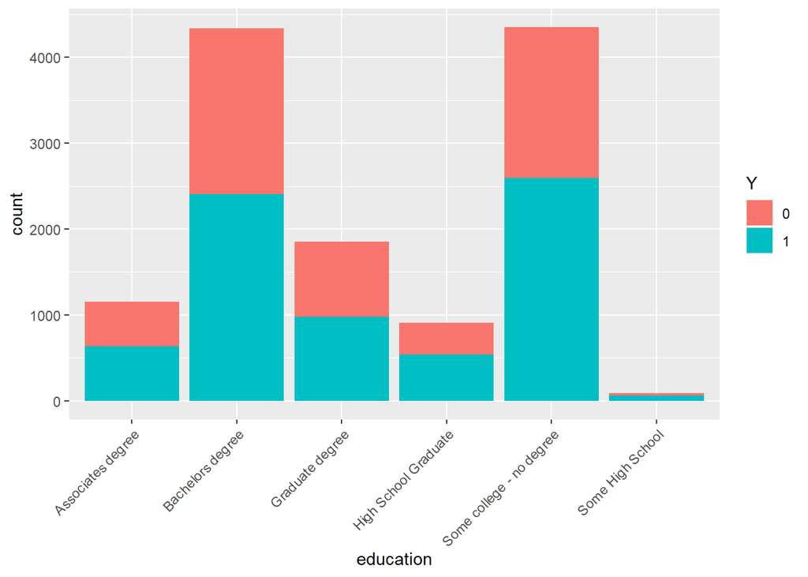

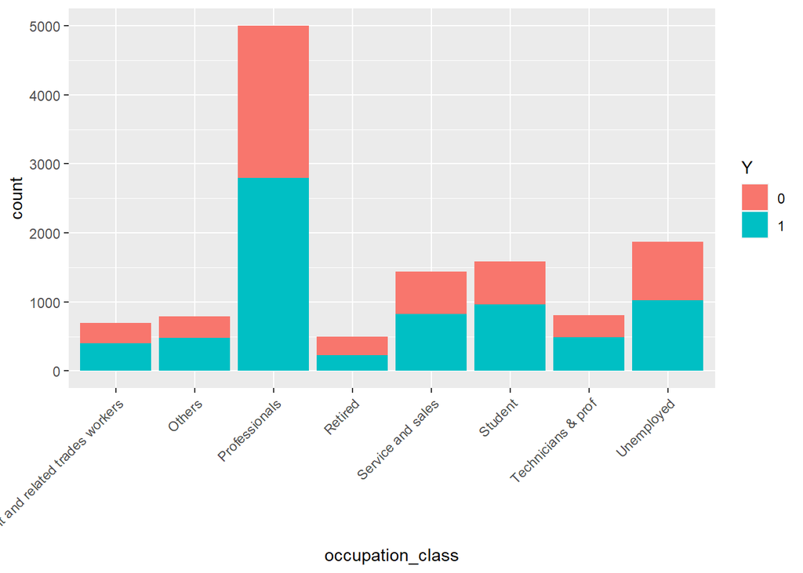

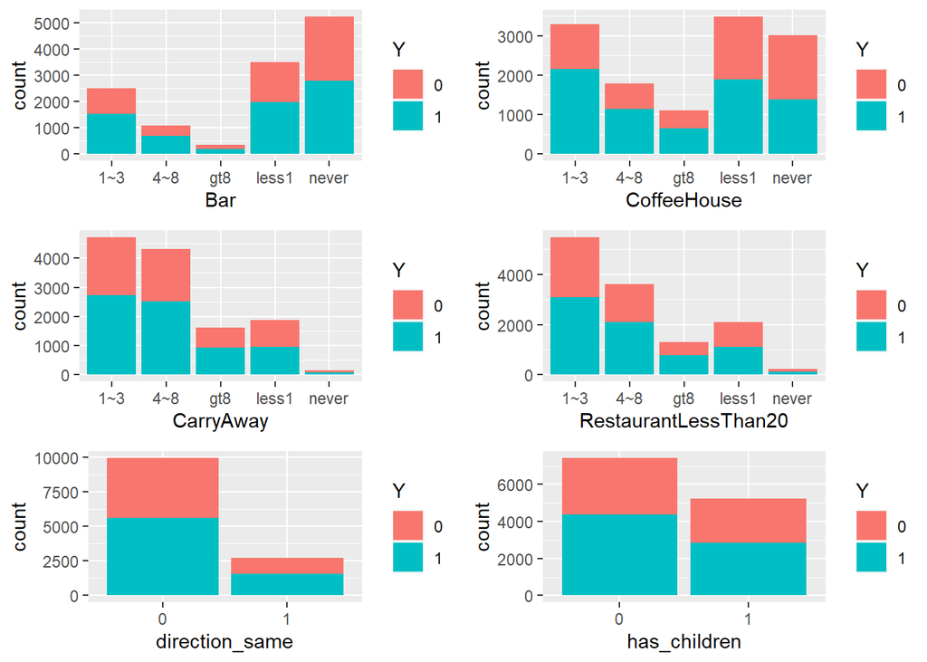

# Modeling

- Droped the variable ‘direction_opp’ that is perfectly correlated with the varible ‘direction_same’.
- ‘occupation’ will be replaced by ‘occupation_class’ in the model.
- ‘expiration’ replaced by numeric variable.

### Dataset Summary

```
## 'data.frame':    12684 obs. of  22 variables:
##  $ destination         : chr  "No Urgent Place" "No Urgent Place" "No Urgent Place" "No Urgent Place" ...
##  $ passanger           : chr  "Alone" "Friends" "Friends" "Friends" ...
##  $ weather             : chr  "Sunny" "Sunny" "Sunny" "Sunny" ...
##  $ temperature         : chr  "55" "80" "80" "80" ...
##  $ coupon              : chr  "Restaurant(<20)" "Coffee House" "Carry out & Take away" "Coffee House" ...
##  $ gender              : chr  "Female" "Female" "Female" "Female" ...
##  $ age                 : chr  "21" "21" "21" "21" ...
##  $ maritalStatus       : chr  "Unmarried partner" "Unmarried partner" "Unmarried partner" "Unmarried partner" ...
##  $ has_children        : Factor w/ 2 levels "0","1": 2 2 2 2 2 2 2 2 2 2 ...
##  $ education           : chr  "Some college - no degree" "Some college - no degree" "Some college - no degree" "Some college - no degree" ...
##  $ income              : chr  "$37500 - $49999" "$37500 - $49999" "$37500 - $49999" "$37500 - $49999" ...
##  $ Bar                 : chr  "never" "never" "never" "never" ...
##  $ CoffeeHouse         : chr  "never" "never" "never" "never" ...
##  $ CarryAway           : chr  "less1" "less1" "less1" "less1" ...
##  $ RestaurantLessThan20: chr  "4~8" "4~8" "4~8" "4~8" ...
##  $ Restaurant20To50    : chr  "1~3" "1~3" "1~3" "1~3" ...
##  $ toCoupon_GEQ15min   : Factor w/ 2 levels "0","1": 1 1 2 2 2 2 2 2 2 2 ...
##  $ toCoupon_GEQ25min   : Factor w/ 2 levels "0","1": 1 1 1 1 1 1 1 1 1 1 ...
##  $ direction_same      : Factor w/ 2 levels "0","1": 1 1 1 1 1 1 1 1 1 1 ...
##  $ Y                   : Factor w/ 2 levels "0","1": 2 1 2 1 1 2 2 2 2 1 ...
##  $ occupation_class    : chr  "Unemployed" "Unemployed" "Unemployed" "Unemployed" ...
##  $ expiration_weightage: num  1.334 0.111 0.111 0.111 1.334 ...
```

## Logistic Regression

The multiple logistic regression is used to predict the probability of class membership based on multiple predictor variables.

### Run model with all parameters on dataset without splitting

- **The most significant variables** (highest z-score and lowest p-value): destination, weather, coupon, CoffeHouse, direction, expiration_weightage
- Insignificant variables (p-value > 0.05): has_children

Being Male, for example, increases the probability of accepting coupon more than being Female. Being age50plus decreases the probability of accepting coupon more than being 21-26.

If we have at least one significant dummy, we can not exclude the variable.

```r
set.seed(123)
full_log_model <- glm(Y ~., data = cleaned_data, family=binomial(link='logit'))
summary(full_log_model)
```

```
##
## Call:
## glm(formula = Y ~ ., family = binomial(link = "logit"), data = cleaned_data)
##
## Deviance Residuals:
##     Min       1Q   Median       3Q      Max
## -2.5209  -1.0270   0.5636   0.9452   2.4255
##
## Coefficients:
##                                     Estimate Std. Error z value Pr(>|z|)
## (Intercept)                        -1.838091   0.243428  -7.551 4.32e-14 ***
## destinationNo Urgent Place          0.729378   0.079469   9.178  < 2e-16 ***
## destinationWork                    -0.098470   0.057699  -1.707 0.087895 .
## passangerFriends                    0.197989   0.072216   2.742 0.006114 **
## passangerKids                      -0.375416   0.093357  -4.021 5.79e-05 ***
## passangerPartner                    0.241605   0.087211   2.770 0.005600 **
## weatherSnowy                        0.148821   0.131895   1.128 0.259183
## weatherSunny                        0.575234   0.079739   7.214 5.43e-13 ***
## temperature55                       0.352177   0.095198   3.699 0.000216 ***
## temperature80                       0.186554   0.085201   2.190 0.028555 *
## couponCarry out & Take away         1.719894   0.072780  23.631  < 2e-16 ***
## couponCoffee House                  0.540885   0.064201   8.425  < 2e-16 ***
## couponRestaurant(<20)               1.522697   0.070068  21.732  < 2e-16 ***
## couponRestaurant(20-50)             0.420023   0.079807   5.263 1.42e-07 ***
## genderMale                          0.220571   0.043062   5.122 3.02e-07 ***
## age26                               0.006942   0.069484   0.100 0.920418
## age31                              -0.157844   0.075490  -2.091 0.036534 *
## age36                              -0.074745   0.086507  -0.864 0.387568
## age41                               0.023716   0.096188   0.247 0.805250
## age46                               0.010569   0.105991   0.100 0.920569
## age50plus                          -0.213765   0.086359  -2.475 0.013312 *
## agebelow21                          0.006049   0.119366   0.051 0.959587
## maritalStatusMarried partner        0.155633   0.112693   1.381 0.167269
## maritalStatusSingle                 0.304920   0.117474   2.596 0.009442 **
## maritalStatusUnmarried partner      0.108520   0.120512   0.900 0.367858
## maritalStatusWidowed                0.268036   0.230731   1.162 0.245365
## has_children1                       0.090748   0.058113   1.562 0.118386
## educationBachelors degree          -0.154507   0.077801  -1.986 0.047043 *
## educationGraduate degree           -0.322835   0.090673  -3.560 0.000370 ***
## educationHigh School Graduate       0.180647   0.104779   1.724 0.084694 .
```

[output cut: 36 more lines]

```
## occupation_classService and sales   0.139935   0.109218   1.281 0.200109
## occupation_classStudent             0.052394   0.115742   0.453 0.650781
## occupation_classTechnicians & prof  0.333988   0.122641   2.723 0.006463 **
## occupation_classUnemployed          0.037353   0.107023   0.349 0.727077
## expiration_weightage                0.683367   0.035104  19.467  < 2e-16 ***
## ---
## Signif. codes:  0 '***' 0.001 '**' 0.01 '*' 0.05 '.' 0.1 ' ' 1
##
## (Dispersion parameter for binomial family taken to be 1)
##
##     Null deviance: 17345  on 12683  degrees of freedom
## Residual deviance: 14983  on 12613  degrees of freedom
## AIC: 15125
##
## Number of Fisher Scoring iterations: 3
```

**Chi-square test** to check the overall effect of variables on the dependent variable

```
## Analysis of Deviance Table
##
## Model: binomial, link: logit
##
## Response: Y
##
## Terms added sequentially (first to last)
##
##
##                      Df Deviance Resid. Df Resid. Dev  Pr(>Chi)
## NULL                                 12683      17345
## destination           2   217.51     12681      17128 < 2.2e-16 ***
## passanger             3    77.17     12678      17051 < 2.2e-16 ***
## weather               2   104.77     12676      16946 < 2.2e-16 ***
## temperature           2     6.24     12674      16940  0.044132 *
## coupon                4   897.31     12670      16042 < 2.2e-16 ***
## gender                1    25.80     12669      16017 3.784e-07 ***
## age                   7    52.77     12662      15964 4.109e-09 ***
## maritalStatus         4    10.99     12658      15953  0.026729 *
## has_children          1     1.39     12657      15952  0.239020
## education             5    35.14     12652      15916 1.414e-06 ***
## income                8    39.17     12644      15877 4.579e-06 ***
## Bar                   4    61.83     12640      15815 1.196e-12 ***
## CoffeeHouse           4   306.51     12636      15509 < 2.2e-16 ***
## CarryAway             4     4.87     12632      15504  0.300435
## RestaurantLessThan20  4     9.66     12628      15494  0.046511 *
## Restaurant20To50      4    24.80     12624      15470 5.509e-05 ***
## toCoupon_GEQ15min     1    38.36     12623      15431 5.878e-10 ***
## toCoupon_GEQ25min     1     3.06     12622      15428  0.080061 .
## direction_same        1    33.88     12621      15394 5.850e-09 ***
## occupation_class      7    19.09     12614      15375  0.007898 **
## expiration_weightage  1   392.28     12613      14983 < 2.2e-16 ***
## ---
## Signif. codes:  0 '***' 0.001 '**' 0.01 '*' 0.05 '.' 0.1 ' ' 1
```

Insignificant coefficients (with p-value > 0.05) according to chi2 check are:

- has_children
- CarryAway
- toCoupon_GEQ25min

**Multicollinearity check**

```r
car::vif(full_log_model)
```

```
##                          GVIF Df GVIF^(1/(2*Df))
## destination          4.225792  2        1.433762
## passanger            3.712514  3        1.244356
## weather              3.717503  2        1.388554
## temperature          4.019478  2        1.415932
## coupon               1.662959  4        1.065639
## gender               1.189566  1        1.090672
## age                  5.085656  7        1.123190
## maritalStatus        3.367204  4        1.163881
## has_children         2.110290  1        1.452684
## education            2.229551  5        1.083482
## income               3.177402  8        1.074928
## Bar                  2.420681  4        1.116843
## CoffeeHouse          2.160636  4        1.101090
## CarryAway            1.997220  4        1.090318
## RestaurantLessThan20 2.689858  4        1.131661
## Restaurant20To50     2.538723  4        1.123510
## toCoupon_GEQ15min    1.335600  1        1.155682
## toCoupon_GEQ25min    1.861808  1        1.364481
## direction_same       2.114032  1        1.453971
## occupation_class     4.526553  7        1.113885
## expiration_weightage 1.176197  1        1.084526
```

There is no problem of mulricollinearity.

Keeping **insignificant variables** in the model may contribute to overfitting. Eliminated **manually, using stepwise regression and penalized regression methods**.

### Stepwise Selection

**Both directions**

```
## Stepwise Model Path
## Analysis of Deviance Table
##
## Initial Model:
## Y ~ destination + passanger + weather + temperature + coupon +
##     gender + age + maritalStatus + has_children + education +
##     income + Bar + CoffeeHouse + CarryAway + RestaurantLessThan20 +
##     Restaurant20To50 + toCoupon_GEQ15min + toCoupon_GEQ25min +
##     direction_same + occupation_class + expiration_weightage
##
## Final Model:
## Y ~ destination + passanger + weather + temperature + coupon +
##     gender + age + maritalStatus + has_children + education +
##     income + Bar + CoffeeHouse + Restaurant20To50 + toCoupon_GEQ15min +
##     toCoupon_GEQ25min + direction_same + occupation_class + expiration_weightage
##
##
##                     Step Df Deviance Resid. Df Resid. Dev      AIC
## 1                                        12613   14982.80 15124.80
## 2            - CarryAway  4 5.233216     12617   14988.03 15122.03
## 3 - RestaurantLessThan20  4 6.592432     12621   14994.62 15120.62
```

**Forward direction**

```
## Stepwise Model Path
## Analysis of Deviance Table
##
## Initial Model:
## Y ~ destination + passanger + weather + temperature + coupon +
##     gender + age + maritalStatus + has_children + education +
##     income + Bar + CoffeeHouse + CarryAway + RestaurantLessThan20 +
##     Restaurant20To50 + toCoupon_GEQ15min + toCoupon_GEQ25min +
##     direction_same + occupation_class + expiration_weightage
##
## Final Model:
## Y ~ destination + passanger + weather + temperature + coupon +
##     gender + age + maritalStatus + has_children + education +
##     income + Bar + CoffeeHouse + CarryAway + RestaurantLessThan20 +
##     Restaurant20To50 + toCoupon_GEQ15min + toCoupon_GEQ25min +
##     direction_same + occupation_class + expiration_weightage
##
##
##   Step Df Deviance Resid. Df Resid. Dev     AIC
## 1                      12613    14982.8 15124.8
```

With forward direction we get the same result as we had with a complete model, forward begins with a Null model (intercept only model)

**Backward direction**

```
## Stepwise Model Path
## Analysis of Deviance Table
##
## Initial Model:
## Y ~ destination + passanger + weather + temperature + coupon +
##     gender + age + maritalStatus + has_children + education +
##     income + Bar + CoffeeHouse + CarryAway + RestaurantLessThan20 +
##     Restaurant20To50 + toCoupon_GEQ15min + toCoupon_GEQ25min +
##     direction_same + occupation_class + expiration_weightage
##
## Final Model:
## Y ~ destination + passanger + weather + temperature + coupon +
##     gender + age + maritalStatus + has_children + education +
##     income + Bar + CoffeeHouse + Restaurant20To50 + toCoupon_GEQ15min +
##     toCoupon_GEQ25min + direction_same + occupation_class + expiration_weightage
##
##
##                     Step Df Deviance Resid. Df Resid. Dev      AIC
## 1                                        12613   14982.80 15124.80
## 2            - CarryAway  4 5.233216     12617   14988.03 15122.03
## 3 - RestaurantLessThan20  4 6.592432     12621   14994.62 15120.62
```

The backward procedure eliminated exactly the same variables as the “both” procedure.

- Different criteria can be assigned to the stepAIC() function for stepwise selection. The default is AIC, which is performed by assigning the argument k to 2.
- We also tried running bestglm, but there is a hard-coded constraint in bestglm (15 predictors means there are 2^15 = 32768 candidate models). In our case we have around 70 variables counting dummies.

### Running 10 fold Cross-Validation on Complete and Stepwise model using training data

**Initially splitting data into train (0.67) and test sets to avoid overfitting**

**1) Model on training set with all variables**

```
## Generalized Linear Model
##
## 8499 samples
##   21 predictor
##    2 classes: '0', '1'
##
## No pre-processing
## Resampling: Cross-Validated (10 fold)
## Summary of sample sizes: 7650, 7649, 7649, 7650, 7649, 7648, ...
## Resampling results:
##
##   Accuracy   Kappa
##   0.6865567  0.3520496
```

**2) Model on training set by dropping columns suggested by stepwise model (CarryAway, RestaurantLessThan20)**

```
## Generalized Linear Model
##
## 8499 samples
##   19 predictor
##    2 classes: '0', '1'
##
## No pre-processing
## Resampling: Cross-Validated (10 fold)
## Summary of sample sizes: 7649, 7649, 7649, 7649, 7649, 7650, ...
## Resampling results:
##
##   Accuracy   Kappa
##   0.6887876  0.3563495
```

**Full model AIC: 10139**  
**Stepwise model AIC: 10134**

According to the bias-variance trade-off, all things equal, simpler model should be always preferred because it is less likely to overfit the training data (less variance).

## Logistic model Predictions on Test set

**Logistic Complete Model Accuracy**

```r
log_reg_prob1 <- predict(log_reg_full, test, type = 'prob')
log_reg_pred1 <- ifelse(log_reg_prob1[2] > 0.5, 1, 0)
mean(log_reg_pred1 == test$Y)
```

```
## [1] 0.6817204
```

**Stepwise Model Accuracy**

```
## [1] 0.6860215
```

**Stepwise model Confusion matrix**

```
## Confusion Matrix and Statistics
##
##           Reference
## Prediction    0    1
##          0 1041  549
##          1  765 1830
##
##                Accuracy : 0.686
##                  95% CI : (0.6717, 0.7001)
##     No Information Rate : 0.5685
##     P-Value [Acc > NIR] : < 2.2e-16
##
##                   Kappa : 0.3507
##
##  Mcnemar's Test P-Value : 3.008e-09
##
##             Sensitivity : 0.7692
##             Specificity : 0.5764
##          Pos Pred Value : 0.7052
##          Neg Pred Value : 0.6547
##              Prevalence : 0.5685
##          Detection Rate : 0.4373
##    Detection Prevalence : 0.6201
##       Balanced Accuracy : 0.6728
##
##        'Positive' Class : 1
##
```

**High sensitivity**: fewer False Negative errors, which are severe types of error for us.  
Low specificity: Many False Positive.

Sensitivity = TP/TP+FN  
The ability of a test to correctly identify people with a coupon  
Speficity = TN/TP+FN

We can change the threshold from 0.5 to 0.45 in order to decrease FN. Focus on sensitivity which is more important for business opportunities.

```
## Confusion Matrix and Statistics
##
##           Reference
## Prediction    0    1
##          0  883  415
##          1  923 1964
##
##                Accuracy : 0.6803
##                  95% CI : (0.6659, 0.6944)
##     No Information Rate : 0.5685
##     P-Value [Acc > NIR] : < 2.2e-16
##
##                   Kappa : 0.3255
##
##  Mcnemar's Test P-Value : < 2.2e-16
##
##             Sensitivity : 0.8256
##             Specificity : 0.4889
##          Pos Pred Value : 0.6803
##          Neg Pred Value : 0.6803
##              Prevalence : 0.5685
##          Detection Rate : 0.4693
##    Detection Prevalence : 0.6898
##       Balanced Accuracy : 0.6572
##
##        'Positive' Class : 1
##
```

**ROC curve**

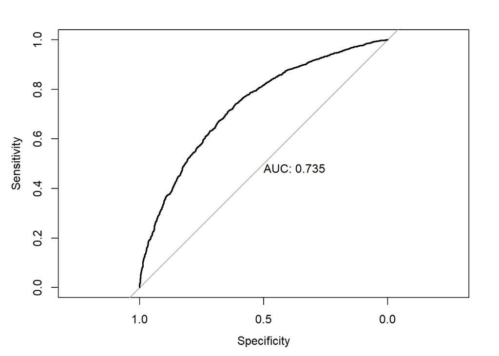

```r
test_roc = roc(test$Y ~ log_reg_prob1$"1", plot = TRUE, print.auc = TRUE)
```

## Penalised models: Lasso and Elastic Net

With dummy variables we have 70 variables, some of the coefficients are already shrinked. We tried to apply Lasso and Elastic Net to find a reduced set of variables resulting to an optimal performing mode (penalty for having too many variables - regularization).

Lasso regression: the coefficients of some less contributive variables are zero. Only the most significant variables are kept in the final model.

Elastic net regression: the combination of ridge and lasso regression. It shrinks some coefficients toward zero and set some coefficients to exactly zero.

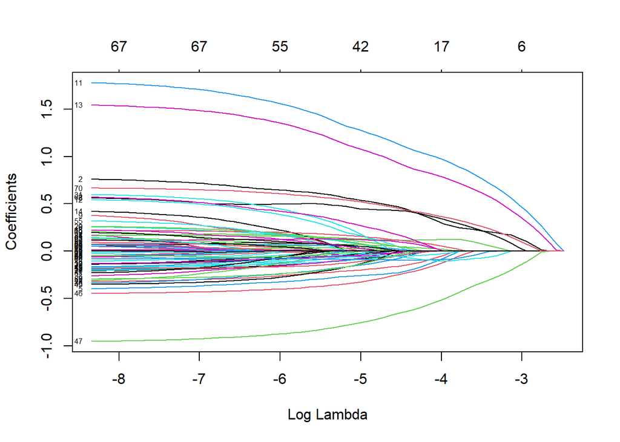

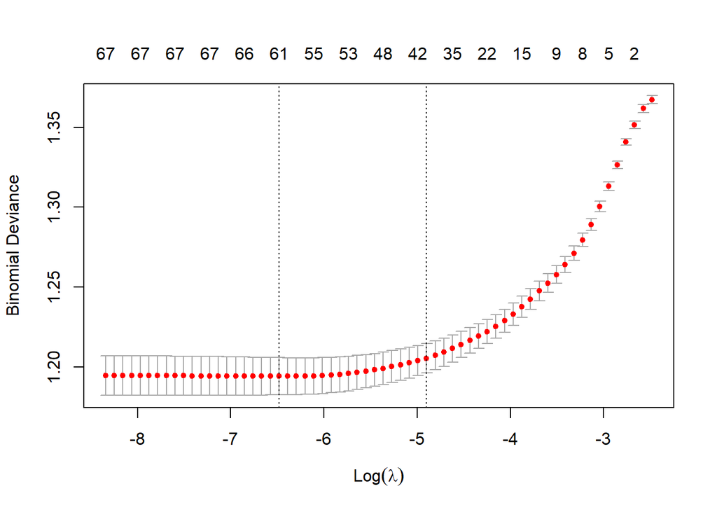

```r
set.seed(123)

x=model.matrix(Y~., data=train)[,-20]
y=as.numeric(train$Y)

x.test <- model.matrix(Y ~., test)[,-20]

fit.lasso= glmnet(x, y, family = "binomial", alpha = 1) #lambda = NULL
plot(fit.lasso,xvar="lambda",label=TRUE)
```

The log of the optimal value of lambda is around -6, which is the one that minimizes the prediction error. **The purpose of regularization is to balance accuracy and simplicity**.

```r
lasso_model <- glmnet(x, y, family = "binomial", alpha = 1, lambda = cv.lasso$lambda.min)
# Display regression coefficients
print('The value of the optimal lambda:')
```

```
## [1] "The value of the optimal lambda:"
```

```r
cv.lasso$lambda.min
```

```
## [1] 0.001530655
```

```r
coef(lasso_model)
```

```
## 71 x 1 sparse Matrix of class "dgCMatrix"
##                                               s0
## (Intercept)                        -1.371630e+00
## (Intercept)                         .
## destinationNo Urgent Place          6.806373e-01
## destinationWork                    -2.675280e-02
## passangerFriends                    1.598453e-01
## passangerKids                      -3.442766e-01
## passangerPartner                    1.982143e-01
## weatherSnowy                        .
## weatherSunny                        4.946506e-01
## temperature55                       2.244876e-01
## temperature80                       1.018110e-01
## couponCarry out & Take away         1.645069e+00
## couponCoffee House                  4.521220e-01
## couponRestaurant(<20)               1.433226e+00
## couponRestaurant(20-50)             2.999037e-01
## genderMale                          2.058610e-01
## age26                               2.084651e-02
## age31                              -1.510088e-01
## age36                              -6.434916e-02
## age41                               .
## age50plus                          -1.682993e-01
## agebelow21                          .
## maritalStatusMarried partner        .
## maritalStatusSingle                 5.538468e-02
## maritalStatusUnmarried partner     -9.628106e-02
## maritalStatusWidowed               -4.531221e-02
## has_children1                       6.627463e-05
## educationBachelors degree          -1.031754e-01
## educationGraduate degree           -2.855151e-01
## educationHigh School Graduate       2.137348e-01
## educationSome college - no degree   7.045093e-02
## educationSome High School           5.126944e-01
## income$12500 - $24999              -6.165148e-03
## income$25000 - $37499               8.644198e-02
## income$37500 - $49999               .
## income$50000 - $62499               1.773591e-01
## income$62500 - $74999              -2.687462e-01
## income$75000 - $87499              -1.495677e-01
```

[output cut: 18 more lines]

```
## Restaurant20To504~8                 1.216481e-01
## Restaurant20To50gt8                 7.037286e-02
## Restaurant20To50less1              -1.741067e-01
## Restaurant20To50never              -2.608974e-01
## toCoupon_GEQ15min1                 -7.441227e-02
## toCoupon_GEQ25min1                  2.919042e-02
## direction_same1                     4.682098e-01
## occupation_classOthers              1.232992e-01
## occupation_classProfessionals       2.746072e-02
## occupation_classRetired            -6.543688e-02
## occupation_classService and sales   .
## occupation_classStudent            -1.457983e-02
## occupation_classTechnicians & prof  1.542427e-01
## occupation_classUnemployed         -7.057785e-03
## expiration_weightage                6.322523e-01
```

```r
#Make predictions on the test data
probabilities <- lasso_model %>% predict(x.test)
predicted.classes <- ifelse(probabilities > 0.5, "1", "0")
#Model accuracy
observed.classes <- test$Y
mean(predicted.classes == observed.classes)
```

```
## [1] 0.655675
```

Results do not show any improvement in the the model performance on the test data.

**ELASTIC NET**

For elastic net regression, alpha is between 0 and 1.

We automatically select the best tuning parameters alpha and lambda

```r
# Build the model
set.seed(123)
elastic <- train(
  Y ~., data = train, method = "glmnet",
  family = "binomial",
  trControl = trainControl("cv", number = 10),
  tuneLength = 5
  )
# Best tuning parameter
elastic$bestTune
```

```
##    alpha      lambda
## 18 0.775 0.001672172
```

**Training model with the best parameters and predicting on the test set**

```r
elastic_model <- glmnet(x, y, family = "binomial", alpha = elastic$bestTune$alpha, lambda = elastic$bestTune$lambda) #lambda = NULL
# Display regression coefficients
#coef(lasso_model)

#Make predictions on the test data

probabilities <- elastic_model %>% predict(x.test)
predicted.classes <- ifelse(probabilities > 0.5, "1", "0")
#Model accuracy
observed.classes <- test$Y
mean(predicted.classes == observed.classes)
```

```
## [1] 0.6563919
```

Elastic Net performs a bit better than Lasso.

## Linear Discriminant Analysis

```r
lda.fit=lda(Y~.,data = train)
lda.fit
```

```
## Call:
## lda(Y ~ ., data = train)
##
## Prior probabilities of groups:
##         0         1
## 0.4315802 0.5684198
##
## Group means:
##   destinationNo Urgent Place destinationWork passangerFriends passangerKids
## 0                  0.4209378       0.2870774        0.1984733    0.08969466
## 1                  0.5549576       0.2196233        0.3044918    0.07120679
##   passangerPartner weatherSnowy weatherSunny temperature55 temperature80
## 0       0.08069793   0.13331516    0.7489095     0.3290622     0.4738277
## 1       0.09314842   0.09232043    0.8298489     0.2862761     0.5435728
##   couponCarry out & Take away couponCoffee House couponRestaurant(<20)
## 0                   0.1090513          0.3710469             0.1496728
## 1                   0.2411509          0.2777893             0.2769613
##   couponRestaurant(20-50) genderMale     age26     age31      age36      age41
## 0              0.15130862  0.4612868 0.1870229 0.1723010 0.11068702 0.08560523
## 1              0.09169944  0.5056924 0.2119644 0.1506934 0.09728835 0.08818050
##        age46 age50plus agebelow21 maritalStatusMarried partner
## 0 0.05261723 0.1589422 0.03489640                    0.4201200
## 1 0.05237011 0.1275098 0.04595322                    0.3877044
##   maritalStatusSingle maritalStatusUnmarried partner maritalStatusWidowed
## 0           0.3454198                      0.1761178          0.015267176
## 1           0.3930863                      0.1718071          0.008693852
##   has_children1 educationBachelors degree educationGraduate degree
## 0     0.4375682                 0.3546892                0.1559433
## 1     0.3968123                 0.3361623                0.1324777
##   educationHigh School Graduate educationSome college - no degree
## 0                    0.06733915                         0.3241549
## 1                    0.07555372                         0.3595529
##   educationSome High School income$12500 - $24999 income$25000 - $37499
## 0               0.005179935             0.1420393             0.1488550
## 1               0.009107845             0.1440696             0.1629062
##   income$37500 - $49999 income$50000 - $62499 income$62500 - $74999
## 0             0.1442203             0.1251363            0.07279171
## 1             0.1446905             0.1397226            0.06085697
##   income$75000 - $87499 income$87500 - $99999 incomeLess than $12500     Bar4~8
## 0            0.08015267            0.07360960             0.08042530 0.07115594
```

[output cut: 89 more lines]

```
## Restaurant20To504~8                 0.106313383
## Restaurant20To50gt8                 0.131032933
## Restaurant20To50less1              -0.194149758
## Restaurant20To50never              -0.320243789
## toCoupon_GEQ15min1                 -0.117938324
## toCoupon_GEQ25min1                  0.154022738
## direction_same1                     0.634476619
## occupation_classOthers              0.258995918
## occupation_classProfessionals       0.112392213
## occupation_classRetired            -0.022867632
## occupation_classService and sales   0.099539936
## occupation_classStudent             0.017292719
## occupation_classTechnicians & prof  0.279203848
## occupation_classUnemployed          0.037525852
## expiration_weightage                0.728072042
```

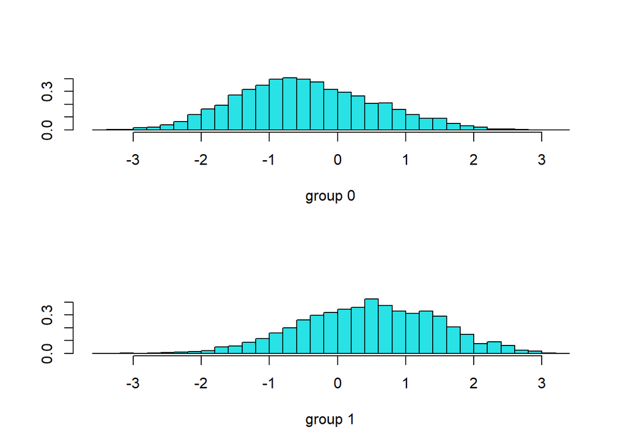

```r
plot(lda.fit)
```

```r
lda.pred=predict(lda.fit,test)$class
table(lda.pred,test$Y)
```

```
##
## lda.pred    0    1
##        0 1038  555
##        1  768 1824
```

```r
mean(lda.pred==test$Y)
```

```
## [1] 0.683871
```

LDA predicts more False Positives as well, accuracy is similar to Logistic Regression (Robust result).

**Improving the accuracy**: - Remove potential outliers (Robust Logistic Regression, remove outliers within categorical variables and combinations of categorical variables) - Random forest and boosting models to capture non-linearities and interactions between the variables - Another option to apply Generalised Additive Models.

# RANDOM FOREST

### Dataset Summary

```
## 'data.frame':    12684 obs. of  22 variables:
##  $ destination         : Factor w/ 3 levels "Home","No Urgent Place",..: 2 2 2 2 2 2 2 2 2 2 ...
##  $ passanger           : Factor w/ 4 levels "Alone","Friends",..: 1 2 2 2 2 2 2 3 3 3 ...
##  $ weather             : Factor w/ 3 levels "Rainy","Snowy",..: 3 3 3 3 3 3 3 3 3 3 ...
##  $ temperature         : Factor w/ 3 levels "30","55","80": 2 3 3 3 3 3 2 3 3 3 ...
##  $ coupon              : Factor w/ 5 levels "Bar","Carry out & Take away",..: 4 3 2 3 3 4 2 4 2 1 ...
##  $ gender              : Factor w/ 2 levels "Female","Male": 1 1 1 1 1 1 1 1 1 1 ...
##  $ age                 : Factor w/ 8 levels "21","26","31",..: 1 1 1 1 1 1 1 1 1 1 ...
##  $ maritalStatus       : Factor w/ 5 levels "Divorced","Married partner",..: 4 4 4 4 4 4 4 4 4 4 ...
##  $ has_children        : Factor w/ 2 levels "0","1": 2 2 2 2 2 2 2 2 2 2 ...
##  $ education           : Factor w/ 6 levels "Associates degree",..: 5 5 5 5 5 5 5 5 5 5 ...
##  $ income              : Factor w/ 9 levels "$100000 or More",..: 4 4 4 4 4 4 4 4 4 4 ...
##  $ Bar                 : Factor w/ 5 levels "1~3","4~8","gt8",..: 5 5 5 5 5 5 5 5 5 5 ...
##  $ CoffeeHouse         : Factor w/ 5 levels "1~3","4~8","gt8",..: 5 5 5 5 5 5 5 5 5 5 ...
##  $ CarryAway           : Factor w/ 5 levels "1~3","4~8","gt8",..: 1 4 4 4 4 4 1 4 4 4 ...
##  $ RestaurantLessThan20: Factor w/ 5 levels "1~3","4~8","gt8",..: 2 2 2 2 2 2 2 2 2 2 ...
##  $ Restaurant20To50    : Factor w/ 5 levels "1~3","4~8","gt8",..: 1 1 1 1 1 1 1 1 1 1 ...
##  $ toCoupon_GEQ15min   : Factor w/ 2 levels "0","1": 1 1 2 2 2 2 2 2 2 2 ...
##  $ toCoupon_GEQ25min   : Factor w/ 2 levels "0","1": 1 1 1 1 1 1 1 1 1 1 ...
##  $ direction_same      : Factor w/ 2 levels "0","1": 1 1 1 1 1 1 1 1 1 1 ...
##  $ Y                   : Factor w/ 2 levels "0","1": 2 1 2 1 1 2 2 2 2 1 ...
##  $ occupation_class    : Factor w/ 8 levels "Craft and related trades workers",..: 8 8 8 8 8 8 8 8 8 8 ...
##  $ expiration_weightage: num  24 2 2 2 24 2 24 2 2 24 ...
```

### Run model on complete dataset

```
##
## Call:
##  randomForest(formula = Y ~ ., data = train)
##                Type of random forest: classification
##                      Number of trees: 500
## No. of variables tried at each split: 4
##
##         OOB estimate of  error rate: 25.19%
## Confusion matrix:
##      0    1 class.error
## 0 2452 1216   0.3315158
## 1  925 3906   0.1914717
```

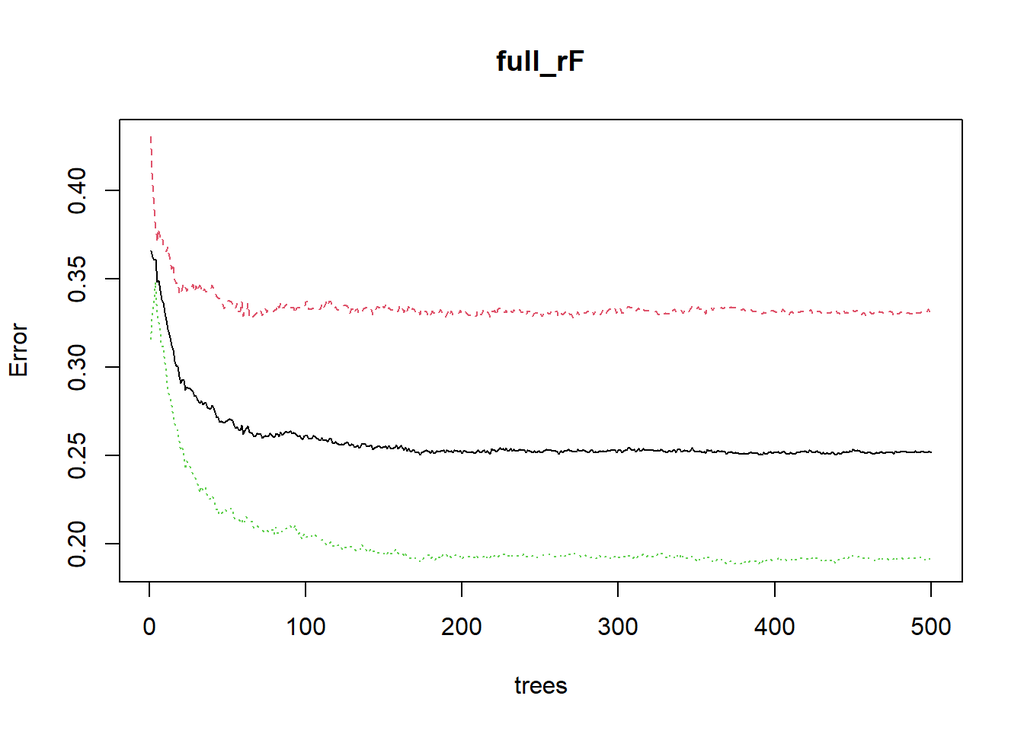

### Tune parameters

```r
  # Perform training with parameters
  rf_classifier = randomForest(Y ~., data = train, ntree=200, mtry=5, importance=TRUE)
  rf_classifier
```

```
##
## Call:
##  randomForest(formula = Y ~ ., data = train, ntree = 200, mtry = 5,      importance = TRUE)
##                Type of random forest: classification
##                      Number of trees: 200
## No. of variables tried at each split: 5
##
##         OOB estimate of  error rate: 25.17%
## Confusion matrix:
##      0    1 class.error
## 0 2477 1191   0.3247001
## 1  948 3883   0.1962327
```

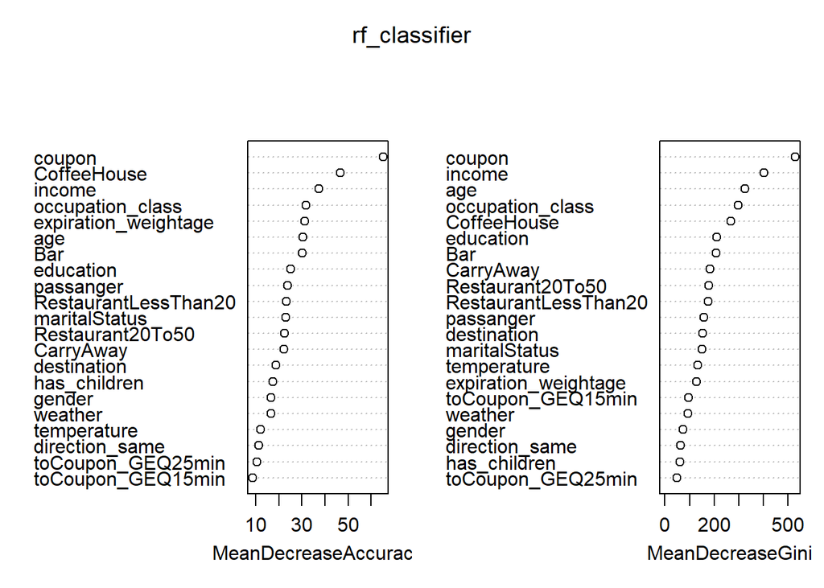

```r
  # plot(rf_classifier)
  varImpPlot(rf_classifier)
```

MeanDecreaseAccuracy: gives a rough estimate of the loss in prediction performance when that particular variable is omitted from the training set. Caveat: if two variables are somewhat redundant, then omitting one of them may not lead to massive gains in prediction performance, but would make the second variable more important.

MeanDecreaseGini: GINI is a measure of node impurity. Think of it like this, if you use this feature to split the data, how pure will the nodes be? Highest purity means that each node contains only elements of a single class. Assessing the decrease in GINI when that feature is omitted leads to an understanding of how important that feature is to split the data correctly.

### Model Evaluation

```
## Confusion Matrix and Statistics
##
##           Reference
## Prediction    0    1
##          0 1212  410
##          1  594 1969
##
##                Accuracy : 0.7601
##                  95% CI : (0.7469, 0.773)
##     No Information Rate : 0.5685
##     P-Value [Acc > NIR] : < 2.2e-16
##
##                   Kappa : 0.505
##
##  Mcnemar's Test P-Value : 7.676e-09
##
##             Sensitivity : 0.8277
##             Specificity : 0.6711
##          Pos Pred Value : 0.7682
##          Neg Pred Value : 0.7472
##              Prevalence : 0.5685
##          Detection Rate : 0.4705
##    Detection Prevalence : 0.6124
##       Balanced Accuracy : 0.7494
##
##        'Positive' Class : 1
##
```

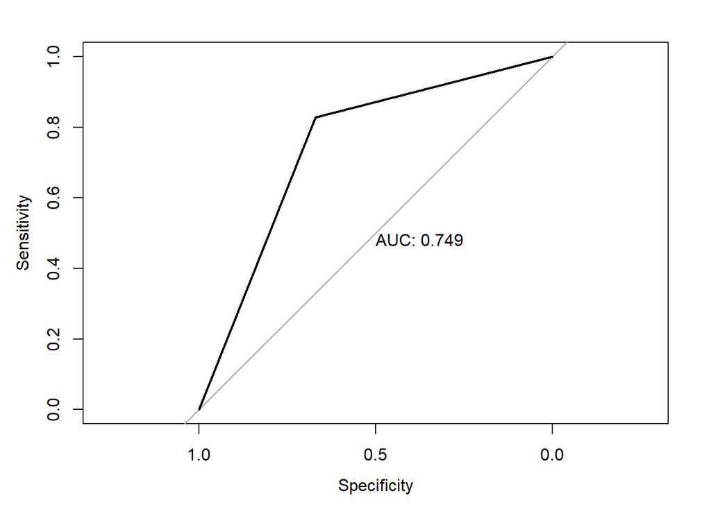

```r
  # classification perfomance
  # auc(test$Y,as.numeric(as.character(prediction_for_table)))
  test_roc = roc(test$Y , as.numeric(as.character(prediction_for_table)), plot = TRUE, print.auc = TRUE)
```

# BOOSTING

### Train Model

```r
# gaussian - regression, bernoulli - classification
  rf_boost <- gbm(Y~.,data=train_boost,distribution="bernoulli",n.trees=5000,shrinkage=0.01,interaction.depth=1, cv.folds=3) #, verbose=F

  best.iter = gbm.perf(rf_boost, method="cv") #Check the best iteration number
```

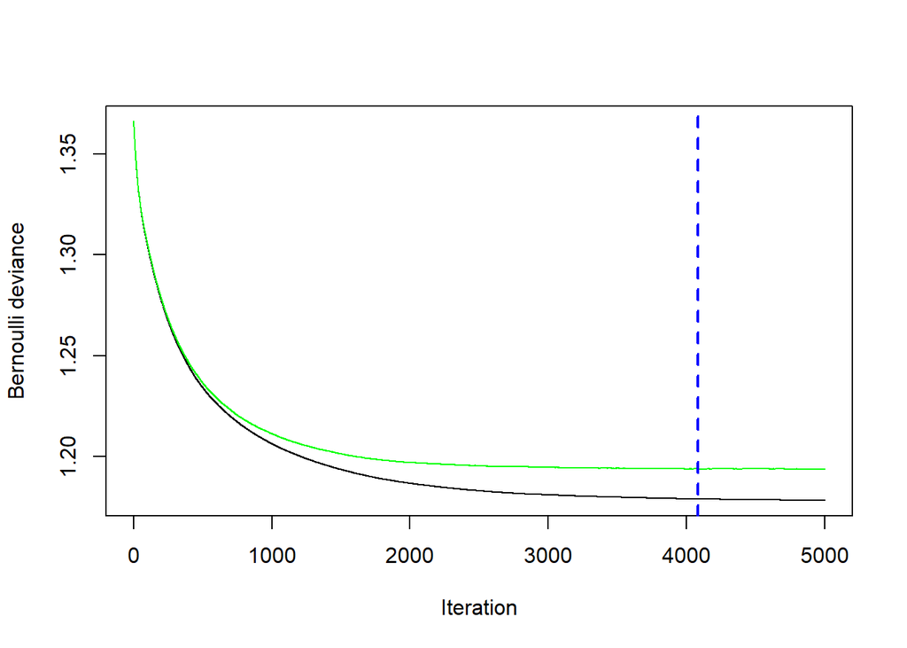

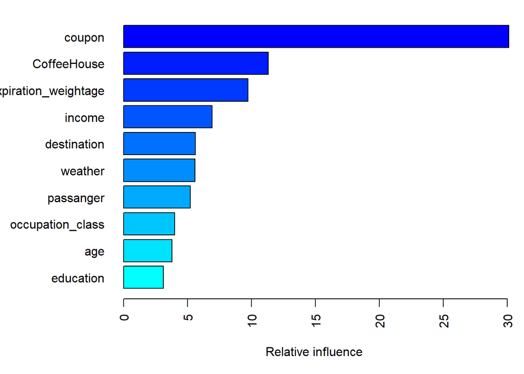

```
##                                       var    rel.inf
## coupon                             coupon 30.1105941
## CoffeeHouse                   CoffeeHouse 11.3105901
## expiration_weightage expiration_weightage  9.7430308
## income                             income  6.9154155
## destination                   destination  5.6196868
## weather                           weather  5.5998788
## passanger                       passanger  5.2079665
## occupation_class         occupation_class  4.0144568
## age                                   age  3.7807999
## education                       education  3.1227566
## Restaurant20To50         Restaurant20To50  1.9246713
## toCoupon_GEQ25min       toCoupon_GEQ25min  1.7884993
## Bar                                   Bar  1.7506133
## direction_same             direction_same  1.7388944
## maritalStatus               maritalStatus  1.5690136
## RestaurantLessThan20 RestaurantLessThan20  1.2921685
## gender                             gender  1.2840792
## CarryAway                       CarryAway  1.1991101
## temperature                   temperature  0.9763819
## toCoupon_GEQ15min       toCoupon_GEQ15min  0.9205985
## has_children                 has_children  0.1307938
```

[output not shown]

```r
  # plot - Summary of the model results, with the importance plot of predictors
  par(mar = c(5, 8, 1, 1))
  summary(rf_boost, cBars = 10,las = 2)
```

### Tune model

```r
 # Using the caret package the get the model preformance in the best iteration
  set.seed(123)
  fitControl = trainControl(method="cv", number=3, returnResamp = "all")

  train_boost$Y <- as.factor(train_boost$Y)
  test_boost$Y <- as.factor(test_boost$Y)

  model2 = train(Y~., data=train_boost, method="gbm",distribution="bernoulli", trControl=fitControl,
                 verbose=F, tuneGrid=data.frame(.n.trees=best.iter, .shrinkage=0.01, .interaction.depth=1, .n.minobsinnode=1))  #

  # model2
  # confusionMatrix(model2)
  mPred = predict(model2, test_boost[,-y_col]) #, na.action = na.pass
  # postResample(mPred, test_boost$Y)
  # confusionMatrix(mPred, test_boost$Y)

  confusionMatrix(
    as.factor(mPred),
    as.factor(test_boost$Y),
    positive = "1"
  )
```

```
## Confusion Matrix and Statistics
##
##           Reference
## Prediction    0    1
##          0  996  549
##          1  810 1830
##
##                Accuracy : 0.6753
##                  95% CI : (0.6608, 0.6894)
##     No Information Rate : 0.5685
##     P-Value [Acc > NIR] : < 2.2e-16
##
##                   Kappa : 0.3264
##
##  Mcnemar's Test P-Value : 1.753e-12
##
##             Sensitivity : 0.7692
##             Specificity : 0.5515
##          Pos Pred Value : 0.6932
##          Neg Pred Value : 0.6447
##              Prevalence : 0.5685
##          Detection Rate : 0.4373
##    Detection Prevalence : 0.6308
##       Balanced Accuracy : 0.6604
##
##        'Positive' Class : 1
##
```

# CLUSTERING

### Dataset summary

```
## 'data.frame':    12684 obs. of  23 variables:
##  $ destination         : Factor w/ 3 levels "Home","No Urgent Place",..: 2 2 2 2 2 2 2 2 2 2 ...
##  $ passanger           : Factor w/ 4 levels "Alone","Friends",..: 1 2 2 2 2 2 2 3 3 3 ...
##  $ weather             : Factor w/ 3 levels "Rainy","Snowy",..: 3 3 3 3 3 3 3 3 3 3 ...
##  $ temperature         : Factor w/ 3 levels "30","55","80": 2 3 3 3 3 3 2 3 3 3 ...
##  $ coupon              : Factor w/ 5 levels "Bar","Carry out & Take away",..: 4 3 2 3 3 4 2 4 2 1 ...
##  $ gender              : Factor w/ 2 levels "Female","Male": 1 1 1 1 1 1 1 1 1 1 ...
##  $ age                 : Factor w/ 8 levels "21","26","31",..: 1 1 1 1 1 1 1 1 1 1 ...
##  $ maritalStatus       : Factor w/ 5 levels "Divorced","Married partner",..: 4 4 4 4 4 4 4 4 4 4 ...
##  $ has_children        : Factor w/ 2 levels "0","1": 2 2 2 2 2 2 2 2 2 2 ...
##  $ education           : Factor w/ 6 levels "Associates degree",..: 5 5 5 5 5 5 5 5 5 5 ...
##  $ income              : Factor w/ 9 levels "$100000 or More",..: 4 4 4 4 4 4 4 4 4 4 ...
##  $ Bar                 : Factor w/ 5 levels "1~3","4~8","gt8",..: 5 5 5 5 5 5 5 5 5 5 ...
##  $ CoffeeHouse         : Factor w/ 5 levels "1~3","4~8","gt8",..: 5 5 5 5 5 5 5 5 5 5 ...
##  $ CarryAway           : Factor w/ 5 levels "1~3","4~8","gt8",..: 4 4 4 4 2 4 1 4 4 4 ...
##  $ RestaurantLessThan20: Factor w/ 5 levels "1~3","4~8","gt8",..: 2 2 2 2 2 2 2 2 2 2 ...
##  $ Restaurant20To50    : Factor w/ 5 levels "1~3","4~8","gt8",..: 1 1 1 1 1 1 1 1 1 1 ...
##  $ toCoupon_GEQ15min   : Factor w/ 2 levels "0","1": 1 1 2 2 2 2 2 2 2 2 ...
##  $ toCoupon_GEQ25min   : Factor w/ 2 levels "0","1": 1 1 1 1 1 1 1 1 1 1 ...
##  $ direction_same      : Factor w/ 2 levels "0","1": 1 1 1 1 1 1 1 1 1 1 ...
##  $ Y                   : Factor w/ 2 levels "0","1": 2 1 2 1 1 2 2 2 2 1 ...
##  $ occupation_class    : Factor w/ 8 levels "Craft and related trades workers",..: 8 8 8 8 8 8 8 8 8 8 ...
##  $ expiration_weightage: num  1.334 0.111 0.111 0.111 1.334 ...
##  $ ID                  : int  1 2 3 4 5 6 7 8 9 10 ...
```

#### Gower distance

**(for mixed type data - categorical and numerical)**

**Cons**: Requires an NxN distance matrix to be calculated, which is computationally intensive. One possible solution for this is to **sample data**, cluster the smaller sample, then treat the clustered sample as training data for k Nearest Neighbors and “classify” the rest of the data.

We create a sample of 1000 observations.

```r
library(cluster)
library(Rtsne)
gower_distance <- function(datafr) {
  gower_dist <- daisy(datafr,
                    metric = "gower",
                    type = list(logratio = 3))
  return(gower_dist)
}
```

**Clustering for entire driving scenario (with all the variables)** Gower distance

```
## 499500 dissimilarities, summarized :
##    Min. 1st Qu.  Median    Mean 3rd Qu.    Max.
##  0.0000  0.5238  0.6190  0.6140  0.7143  0.9524
## Metric :  mixed ;  Types = N, N, N, N, N, N, N, N, N, N, N, N, N, N, N, N, N, N, N, N, I
## Number of objects : 1000
```

Gower distance = 0 minimum. 1 - maximum distance.  
We have more dissimilar observaions in the dataset.

```r
# Output most similar pair
gower_mat <- as.matrix(gower_dist)
sample_clust[
  which(gower_mat == min(gower_mat[gower_mat != min(gower_mat)]),
        arr.ind = TRUE)[1, ], ]
```

```
##          destination passanger weather temperature          coupon gender
## 2777            Work     Alone   Sunny          55 Restaurant(<20) Female
## 2757 No Urgent Place     Alone   Sunny          55 Restaurant(<20) Female
##         age   maritalStatus has_children        education          income   Bar
## 2777 50plus Married partner            1 Bachelors degree $50000 - $62499 never
## 2757 50plus Married partner            1 Bachelors degree $50000 - $62499 never
##      CoffeeHouse CarryAway RestaurantLessThan20 Restaurant20To50
## 2777       never     less1                less1            less1
## 2757       never     less1                less1            less1
##      toCoupon_GEQ15min toCoupon_GEQ25min direction_same Y occupation_class
## 2777                 0                 0              0 1    Professionals
## 2757                 0                 0              0 1    Professionals
##      expiration_weightage   ID
## 2777              1.33374 2777
## 2757              1.33374 2757
```

```r
# Output most dissimilar pair
sample_clust[
  which(gower_mat == max(gower_mat[gower_mat != max(gower_mat)]),
        arr.ind = TRUE)[1, ], ]
```

```
##          destination passanger weather temperature       coupon gender age
## 466             Home     Alone   Sunny          55          Bar   Male  31
## 2463 No Urgent Place   Partner   Sunny          80 Coffee House Female  21
##          maritalStatus has_children                education          income
## 466             Single            1     High School Graduate $50000 - $62499
## 2463 Unmarried partner            0 Some college - no degree $12500 - $24999
##      Bar CoffeeHouse CarryAway RestaurantLessThan20 Restaurant20To50
## 466  gt8         gt8       gt8                  gt8              gt8
## 2463 1~3       less1       1~3                  1~3            less1
##      toCoupon_GEQ15min toCoupon_GEQ25min direction_same Y occupation_class
## 466                  0                 0              1 1    Professionals
## 2463                 1                 0              0 1       Unemployed
##      expiration_weightage   ID
## 466              1.333740  466
## 2463             0.111145 2463
```

**K-medoids Clustering**

Partitioning around medoids with custom distance matrix

The k-medoids problem is a clustering problem similar to k-means.In contrast to the k-means algorithm, k-medoids chooses **actual data points as centers (medoids or exemplars)**, and thereby allows for **greater interpretability of the cluster centers** than in k-means.

k-medoids can be used with arbitrary dissimilarity measures, whereas k-means generally requires Euclidean distance for efficient solutions. Because **k-medoids minimizes a sum of pairwise dissimilarities** instead of a sum of squared Euclidean distances, it is **more robust to noise and outliers than k-means**.

Selecting the number of clusters k using **silhouette width**, an internal validation metric which is an aggregated measure of how similar an observation is to its own cluster compared its closest neighboring cluster. The metric can range from -1 to 1, where higher values are better.

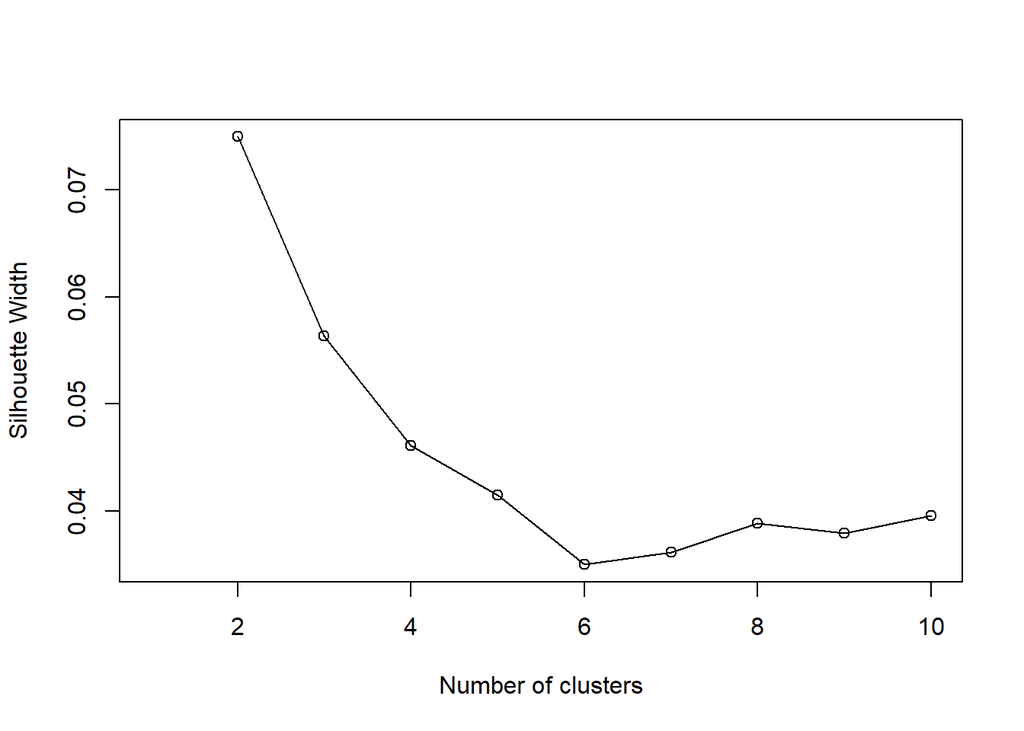

```r
library(Rtsne)
# Calculate silhouette width for many k using PAM
sil_width <- c(NA)
for(i in 2:10){
  pam_fit <- pam(gower_dist,
                 diss = TRUE,
                 k = i)
  sil_width[i] <- pam_fit$silinfo$avg.width
}

# Plot sihouette width (higher is better)
plot(1:10, sil_width,
     xlab = "Number of clusters",
     ylab = "Silhouette Width")
lines(1:10, sil_width)
```

**Interpret the clusters by running summary on each cluster:**

In cluster 1 (430): higher frequency for Alone, Male, 21, Single, no_children, Some college - no degree/Bachelors degree, lower income, Student

In cluster 2 (570): higher frequency for No Urgent Place, Friends/Alone, Female, 50plus, Married_Partner, has_children, Bachelors degree/Graduate, higher income,Restaurant20To50, toCoupon_GEQ15min, Professionals

Other characteristics are overlapping for both the clusters, so we can explore if only the personal characteriscts and not the driving scenario lead to the cluster separation.

Distribution of Y is the same in the clusters (58% accepted in the first group and 55% in the second).

```r
set.seed(123)
pam_fit <- pam(gower_dist, diss = TRUE, k = 2)
pam_results <- sample_clust %>%
  dplyr::select(-ID) %>%
  mutate(cluster = pam_fit$clustering) %>%
  group_by(cluster) %>%
  do(the_summary = summary(.))
#pam_results$the_summary
```

```r
sample_clust[pam_fit$medoids, ]
```

```
##           destination passanger weather temperature            coupon gender
## 12584            Home     Alone   Sunny          80 Restaurant(20-50)   Male
## 9753  No Urgent Place   Friends   Sunny          80      Coffee House Female
##          age   maritalStatus has_children                education
## 12584     21          Single            0 Some college - no degree
## 9753  50plus Married partner            1         Bachelors degree
##                income   Bar CoffeeHouse CarryAway RestaurantLessThan20
## 12584 $12500 - $24999 never       never       1~3                  1~3
## 9753  $100000 or More never       less1       4~8                  1~3
##       Restaurant20To50 toCoupon_GEQ15min toCoupon_GEQ25min direction_same Y
## 12584            less1                 0                 0              0 0
## 9753               1~3                 1                 0              0 1
##       occupation_class expiration_weightage    ID
## 12584          Student              1.33374 12584
## 9753     Professionals              1.33374  9753
```

One way to visualize many variables in a lower dimensional space is with t-distributed stochastic neighborhood embedding, or t-SNE. A dimensionality reduction technique that tries to preserve local structure so as to make clusters visible in a 2D or 3D visualization.

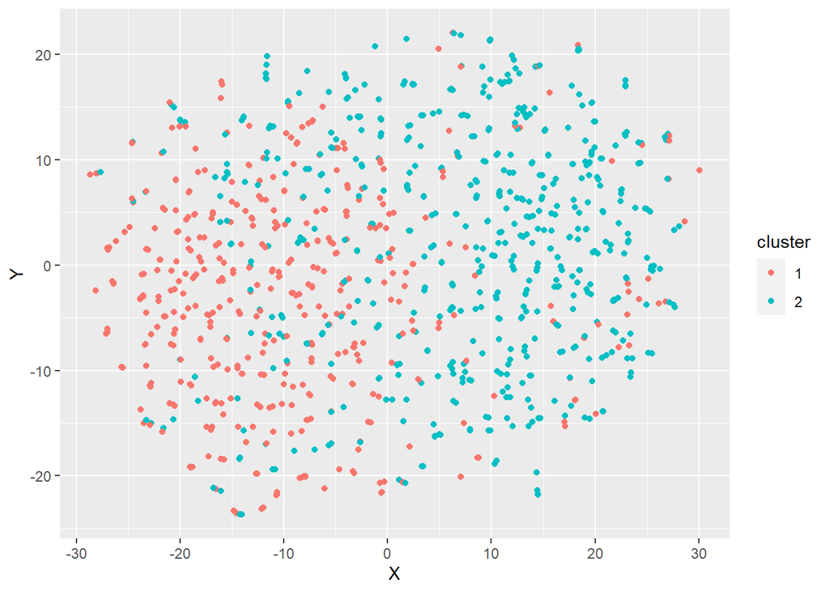

```r
tsne_obj <- Rtsne(gower_dist, is_distance = TRUE)
tsne_data <- tsne_obj$Y %>%
  data.frame() %>%
  setNames(c("X", "Y")) %>%
  mutate(cluster = factor(pam_fit$clustering),
         name = sample_clust$ID)
ggplot(aes(x = X, y = Y), data = tsne_data) +
  geom_point(aes(color = cluster))
```

**Clusters are overlapping**. Blue points are closer to blue cluster medoid for the metrics, however, it’s impossible to show it in a 2D space due to the fact that only 18% of variance of the data explained after dim reduction.

## Agglomerative clustering

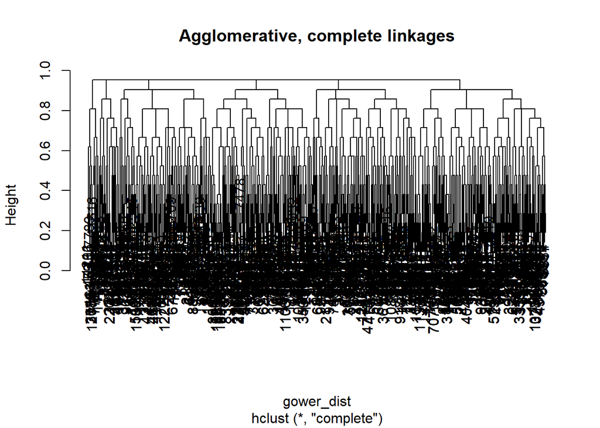

```r
aggl.clust.c <- hclust(gower_dist, method = "complete")
  plot(aggl.clust.c,
      main = "Agglomerative, complete linkages")
```

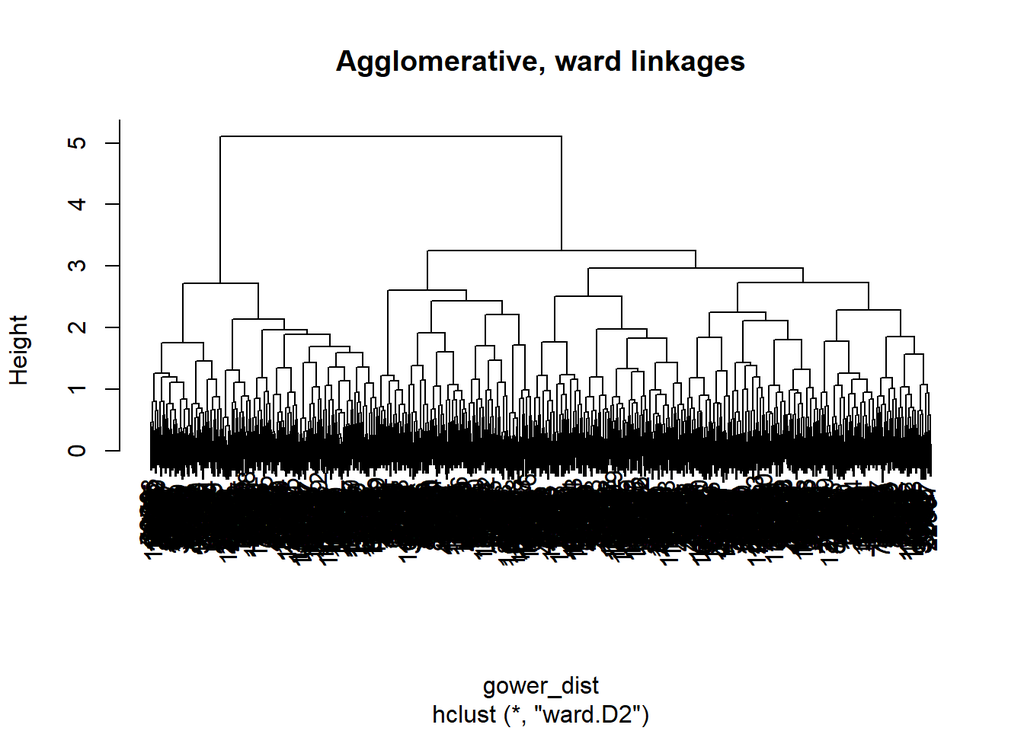

```r
#
# aggl.clust.c <- hclust(gower_dist, method = "average")
# plot(aggl.clust.c,
#      main = "Agglomerative, average linkages")
#
# aggl.clust.c <- hclust(gower_dist, method = "single")
# plot(aggl.clust.c,
#      main = "Agglomerative, single linkages")

aggl.clust.w <- hclust(gower_dist, method = "ward.D2")
plot(aggl.clust.w,
     main = "Agglomerative, ward linkages")
```

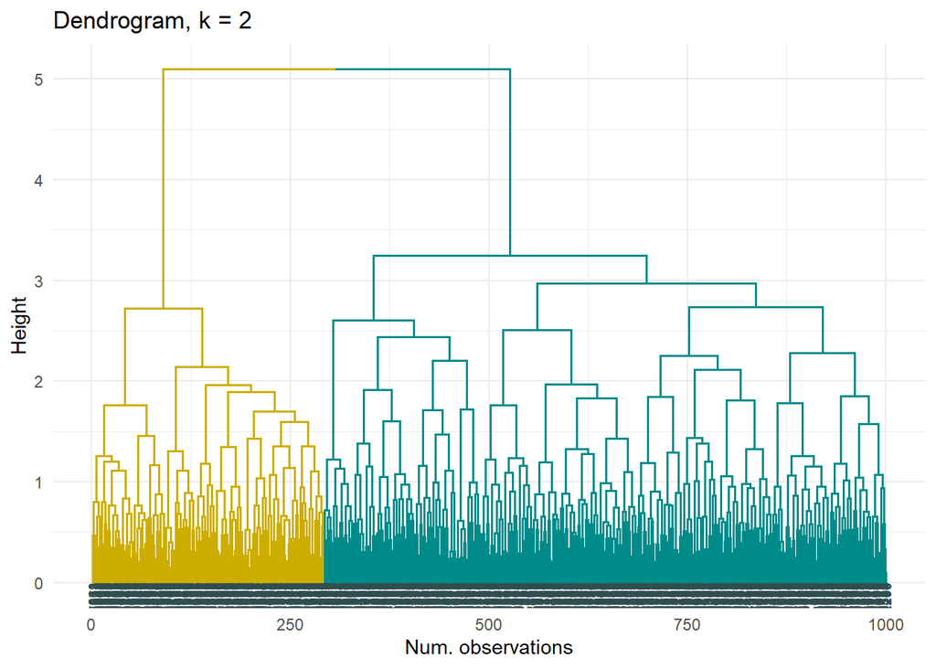

```r
# hierarchical clustering using Ward linkage

dendro <- as.dendrogram(aggl.clust.w)
dendro.col <- dendro %>%
  set("branches_k_color", k = 2, value =   c( "gold3", "darkcyan")) %>%
  set("branches_lwd", 0.6) %>%
  set("labels_colors",
      value = c("darkslategray")) %>%
  set("labels_cex", 0.5)
ggd1 <- as.ggdend(dendro.col)
ggplot(ggd1, theme = theme_minimal()) +
  labs(x = "Num. observations", y = "Height", title = "Dendrogram, k = 2")
```

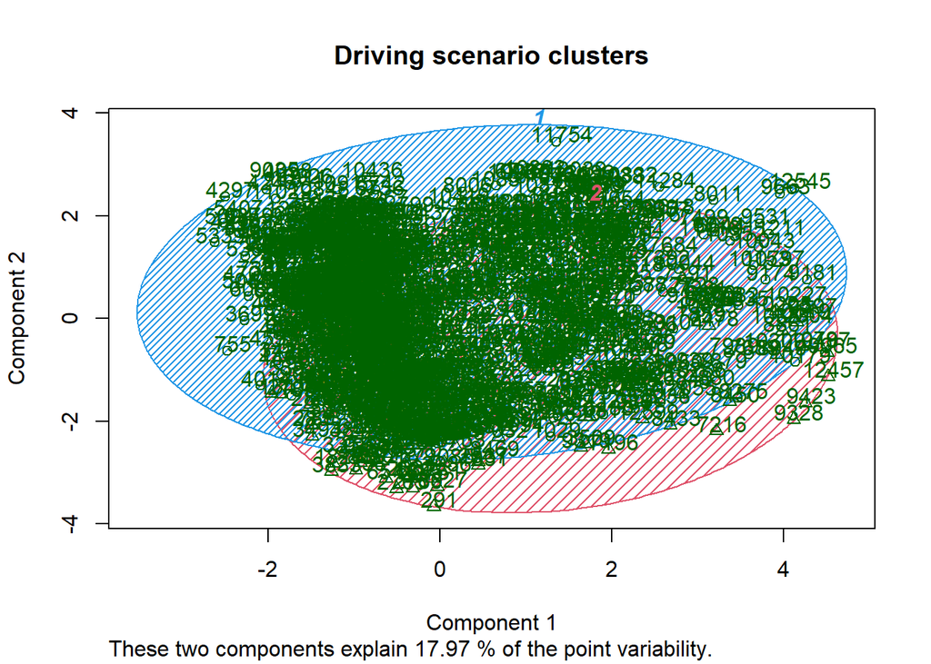

```r
groups <- cutree(aggl.clust.w, k=2) # cut tree into 5 clusters
clusplot(sample_clust, groups, color=TRUE, shade=TRUE,
         labels=2, lines=0, main= 'Driving scenario clusters')
```

## Clustering evaluation - Rand index

Rand Index looks at similarity between any two clustering methods. The Rand Index gives a value between 0 and 1,where 1 means the two clustering outcomes match identically

```
## [1] 0.5421742
```

```
## [1] 0.4995315
```

```
## [1] 0.5045045
```

## Another startegy - groups based on personal characteristics

**Dataset Information**

```
## 'data.frame':    1000 obs. of  9 variables:
##  $ gender          : Factor w/ 2 levels "Female","Male": 1 2 1 1 1 2 2 1 2 2 ...
##  $ age             : Factor w/ 8 levels "21","26","31",..: 1 1 2 3 2 1 5 6 2 1 ...
##  $ maritalStatus   : Factor w/ 5 levels "Divorced","Married partner",..: 4 3 4 2 4 4 3 1 3 3 ...
##  $ has_children    : Factor w/ 2 levels "0","1": 1 1 1 1 1 1 1 2 1 1 ...
##  $ education       : Factor w/ 6 levels "Associates degree",..: 5 5 2 5 5 5 4 2 4 5 ...
##  $ income          : Factor w/ 9 levels "$100000 or More",..: 2 1 4 1 5 3 2 3 2 9 ...
##  $ Y               : Factor w/ 2 levels "0","1": 2 2 2 1 2 1 2 2 2 2 ...
##  $ occupation_class: Factor w/ 8 levels "Craft and related trades workers",..: 8 6 7 3 2 5 1 2 5 6 ...
##  $ ID              : int  2463 2511 10419 8718 12483 2986 1842 9334 3371 11638 ...
```

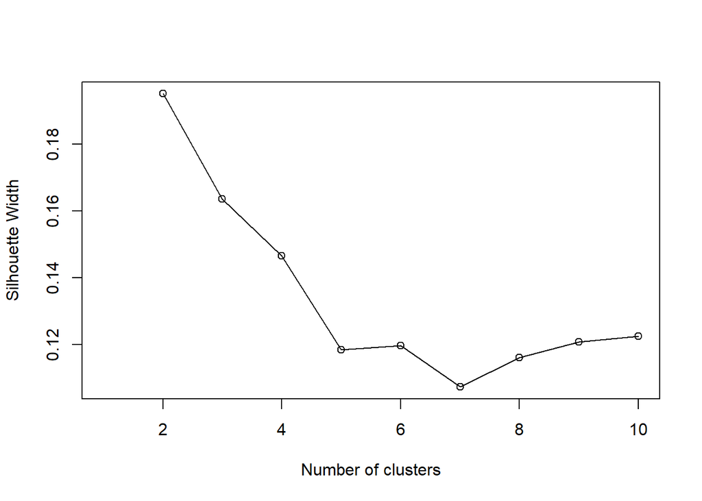

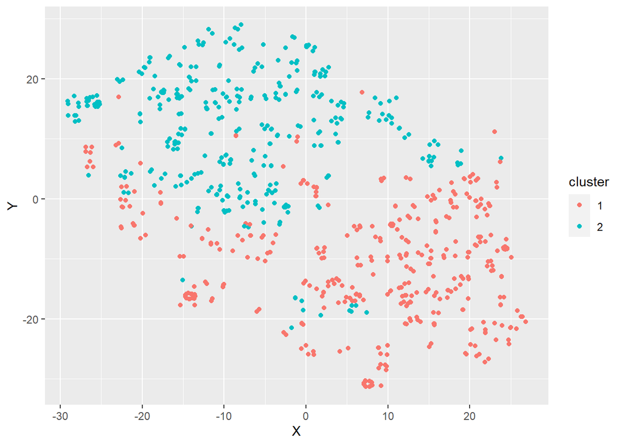

## Group by characteristics of coupon only

```
## 'data.frame':    1000 obs. of  6 variables:
##  $ coupon              : Factor w/ 5 levels "Bar","Carry out & Take away",..: 3 3 3 5 1 2 3 4 3 1 ...
##  $ toCoupon_GEQ15min   : Factor w/ 2 levels "0","1": 2 2 1 2 2 2 1 1 1 2 ...
##  $ toCoupon_GEQ25min   : Factor w/ 2 levels "0","1": 1 2 1 1 1 1 1 1 1 1 ...
##  $ Y                   : Factor w/ 2 levels "0","1": 2 2 2 1 2 1 2 2 2 2 ...
##  $ expiration_weightage: num  0.111 0.111 1.334 0.111 0.111 ...
##  $ ID                  : int  2463 2511 10419 8718 12483 2986 1842 9334 3371 11638 ...
```

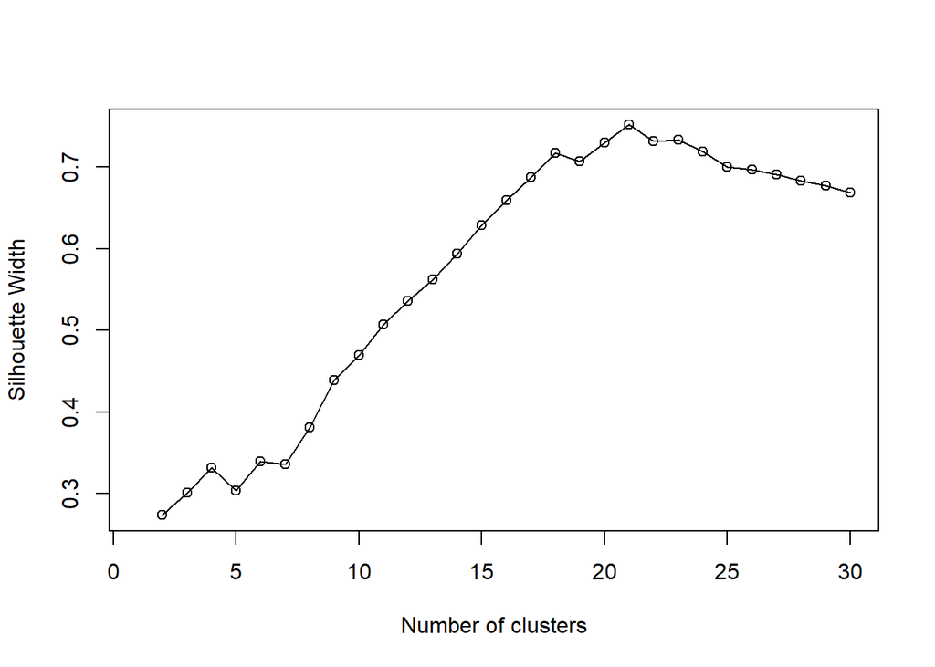

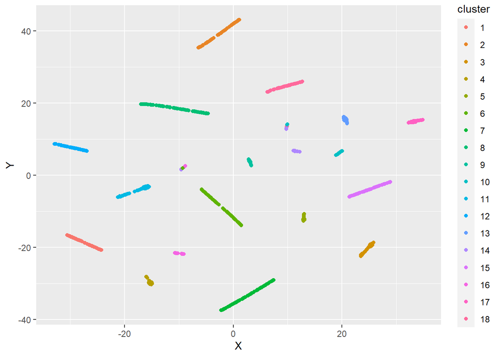

```r
pam_results$the_summary
```

```
## [[1]]
##                    coupon   toCoupon_GEQ15min toCoupon_GEQ25min Y
##  Bar                  : 0   0: 0              0:59              0: 0
##  Carry out & Take away: 0   1:66              1: 7              1:66
##  Coffee House         :66
##  Restaurant(<20)      : 0
##  Restaurant(20-50)    : 0
##
##  expiration_weightage    cluster
##  Min.   :0.1111       Min.   :1
##  1st Qu.:0.1111       1st Qu.:1
##  Median :1.3337       Median :1
##  Mean   :0.7595       Mean   :1
##  3rd Qu.:1.3337       3rd Qu.:1
##  Max.   :1.3337       Max.   :1
##
## [[2]]
##                    coupon   toCoupon_GEQ15min toCoupon_GEQ25min Y
##  Bar                  : 0   0:85              0:85              0: 0
##  Carry out & Take away: 0   1: 0              1: 0              1:85
##  Coffee House         :85
##  Restaurant(<20)      : 0
##  Restaurant(20-50)    : 0
##
##  expiration_weightage    cluster
##  Min.   :0.1111       Min.   :2
##  1st Qu.:0.1111       1st Qu.:2
##  Median :0.1111       Median :2
##  Mean   :0.6865       Mean   :2
##  3rd Qu.:1.3337       3rd Qu.:2
##  Max.   :1.3337       Max.   :2
##
## [[3]]
##                    coupon   toCoupon_GEQ15min toCoupon_GEQ25min Y
##  Bar                  : 0   0: 0              0:43              0:47
##  Carry out & Take away: 0   1:47              1: 4              1: 0
##  Coffee House         : 0
##  Restaurant(<20)      : 0
##  Restaurant(20-50)    :47
##
```

[output cut: 232 more lines]

```
## [[18]]
##                    coupon   toCoupon_GEQ15min toCoupon_GEQ25min Y
##  Bar                  : 0   0:66              0:66              0:66
##  Carry out & Take away: 3   1: 0              1: 0              1: 0
##  Coffee House         :63
##  Restaurant(<20)      : 0
##  Restaurant(20-50)    : 0
##
##  expiration_weightage    cluster
##  Min.   :0.1111       Min.   :18
##  1st Qu.:0.1111       1st Qu.:18
##  Median :1.3337       Median :18
##  Mean   :0.8336       Mean   :18
##  3rd Qu.:1.3337       3rd Qu.:18
##  Max.   :1.3337       Max.   :18
```